# Vector maps

AJ Irwin

2026-03-23

## Vector maps

- Packages
- Key functions
- Data for maps
- Coloring regions
- Adding points
- Projections

## Packages

```r
library(tidyverse, quietly = TRUE)
# library(ggmap)
library(rnaturalearth)
library(rnaturalearthdata) # devtools::install_github("ropensci/rnaturalearthdata")
library(rnaturalearthhires) # devtools::install_github("ropensci/rnaturalearthhires")
library(sf) # simple features = map objects (points, lines, areas)
library(ggrepel)
```

Lots of other packages in examples (notes and wider internet): `sf` (simple features), `terra`, and many more.

## Essential examples

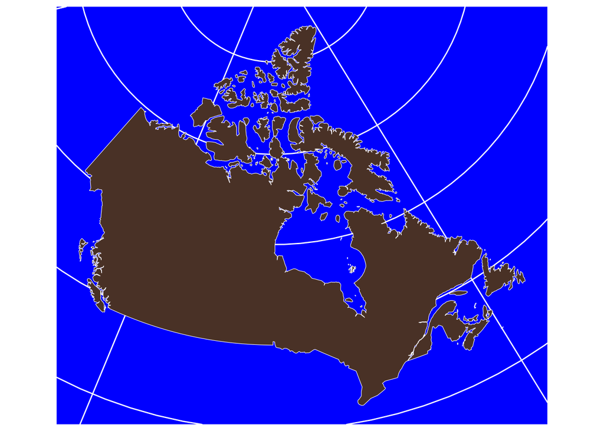

```r
canada_sf <- st_as_sf(maps::map("world", "Canada", plot = FALSE, fill = TRUE))

ggplot(data = canada_sf) +
  geom_sf(fill = "#5C4033", color = "white", size = 0.2) +
  # coord_sf using the official Canada Atlas Lambert projection (EPSG:3978)
  coord_sf(crs = st_crs(3978)) +
  theme(
    panel.background = element_rect(fill = "#0022FF"),
    panel.border = element_blank(),
    axis.text = element_blank(),
    axis.ticks = element_blank()  ) +
  labs(x = NULL, y = NULL)
```

### Map with cities

Cities

```r
city_coords <- tribble( ~city, ~lat, ~long,
  "Vancouver",    49.2827,    -123.1207,
  "Calgary",  51.0447,    -114.0719,
  "Edmonton", 53.5461,    -113.4938,
  "Toronto",  43.6532,    -79.3832,
  "Ottawa",   45.4215,    -75.6972,
  "Montreal", 45.5017,    -73.5673,
  "Halifax", 44.6488, -63.5752) |>
  st_as_sf(coords = c("long", "lat"), crs = 4326)
```

Map

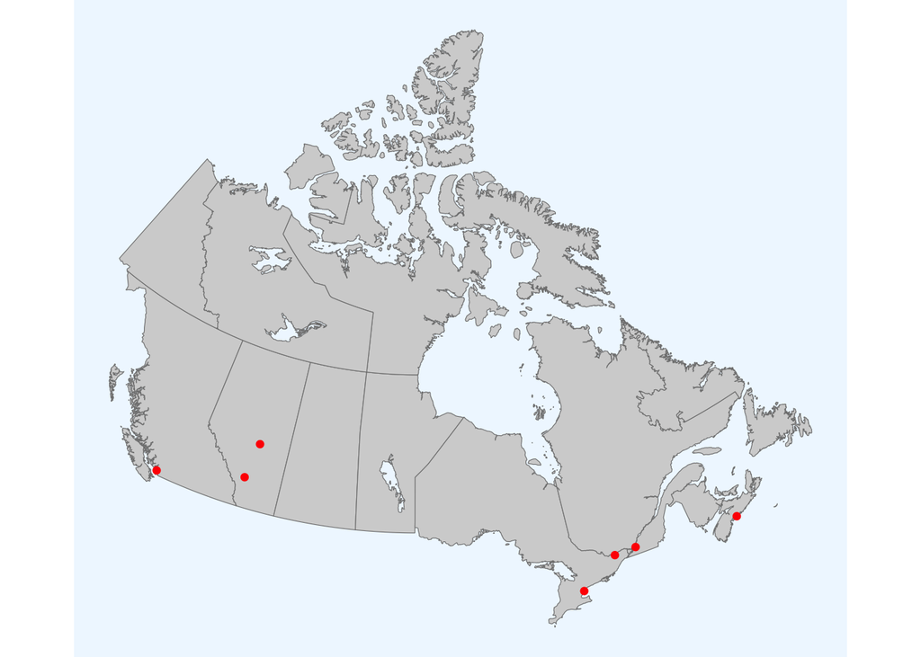

```r
canada <- ne_states(country = "canada", returnclass = "sf")
map1 <- canada |> ggplot() +
  geom_sf(fill = "lightgray", colour = "#7f7f7f") +
  geom_sf(data = city_coords, color = "red") +
  theme_void() +
  theme(
    panel.background = element_rect(fill = "aliceblue"),
    panel.grid = element_blank()
  ) +
    coord_sf(crs = st_crs(3978))  # Ask LLM for help
map1
```

Add labels

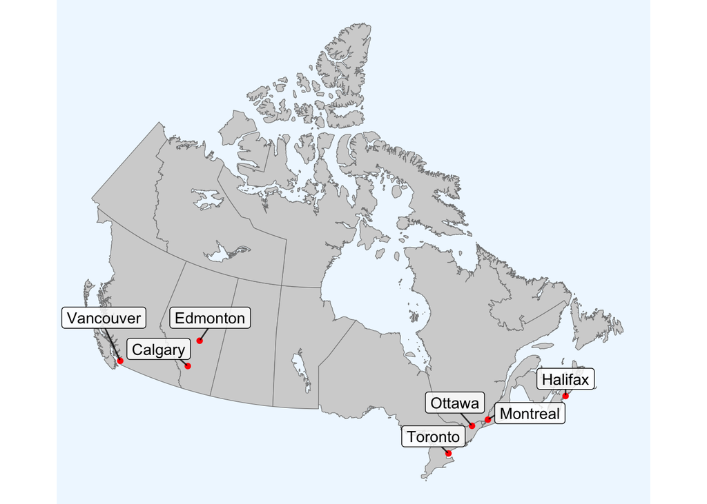

```r
map1 + geom_label_repel(
    data = city_coords,
    aes(label = city, geometry = geometry),
    stat = "sf_coordinates",
    min.segment.length = 0, # Always draw the line
    colour = "black",
    fill = "white",
    alpha = 0.8,
    nudge_y = 100000 # Shift labels up (in meters if using CRS 3347)
  )
```

## More examples

### Functions

- `map_data` (get data for a map, part of ggplot2)
- `geom_map` (draw a map)
  - aesthetics: `map_id` (column with names for each region to be plotted), required argument: `map` (a data frame with the map data)
- `expand_limits` (if part of your map is not showing)
- `coord_map` (projections, Mercator is default)

### Data for map

```r
m1 <- map_data("world")
m1lake <- map_data("lakes")
# m1 |> filter(region == "Canada")
# france, italy, lakes, nz, county (USA), state (USA), usa (coastline), world, world2 (centered on Pacific Ocean)
# canada.cities, world.cities
# see: help(package = "maps") for details
```

There are many “regions” and “subregions” within some of these maps:

```r
count(m1, region) |> head()
```

```
##           region   n
## 1    Afghanistan 410
## 2        Albania 113
## 3        Algeria 383
## 4 American Samoa   8
## 5        Andorra  19
## 6         Angola 338
```

```r
m1 |> filter(region == "Canada") |> count(subregion)
```

```
##                             subregion    n
## 1                                  10    6
## 2                                 100   37
## 3                                 103   21
## 4                                 106   11
## 5                                  11   12
## 6                                 110   19
## 7                                 122   10
## 8                                 123   14
## 9                                 126   24
## 10                                127   17
## 11                                128   22
## 12                                131   29
## 13                                140   22
## 14                                146   12
```

[output cut: 126 more lines]

Political borders and territorial disputes: maps will undoubtedly be incomplete, inaccurate, or conflict with some people’s political views whether in Canada (Québec, Labrador), France (St Pierre & Miquelon), China, Palestine, Russia, etc.

## Make a map

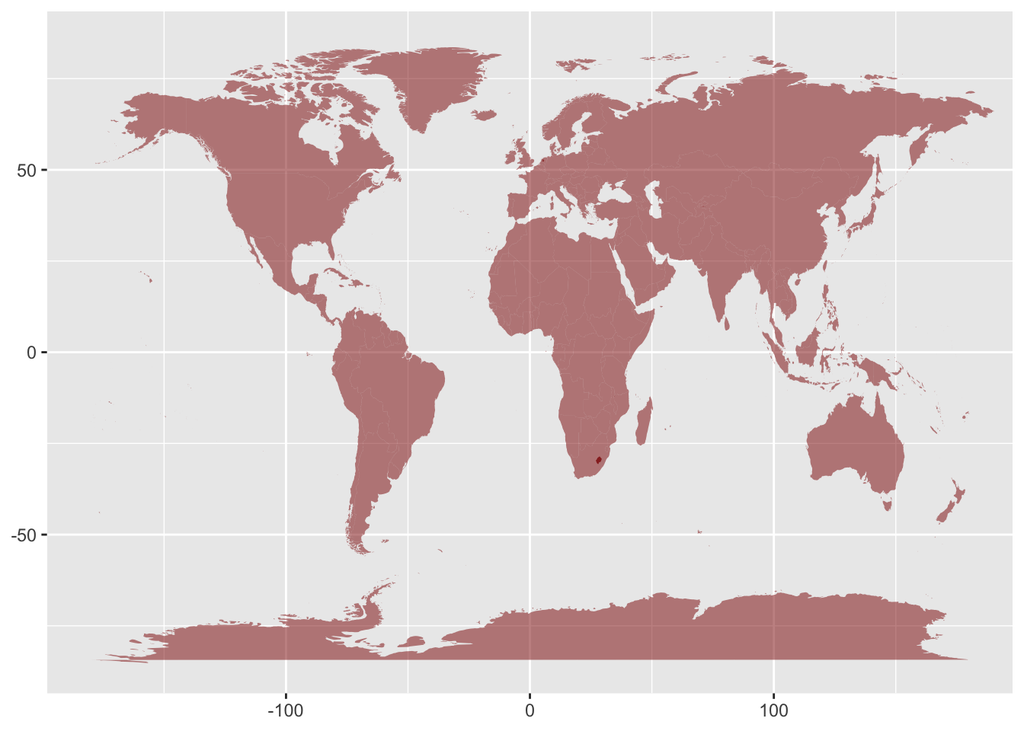

```r
ggplot(m1, aes(map_id = region)) +
    geom_map(fill = "darkred", color = NA,
             linewidth = 0.1, map = m1, alpha = 0.5) +
  expand_limits(x = c(-180,180), y = c(-85, 85) )
```

Combine the land and lake maps.

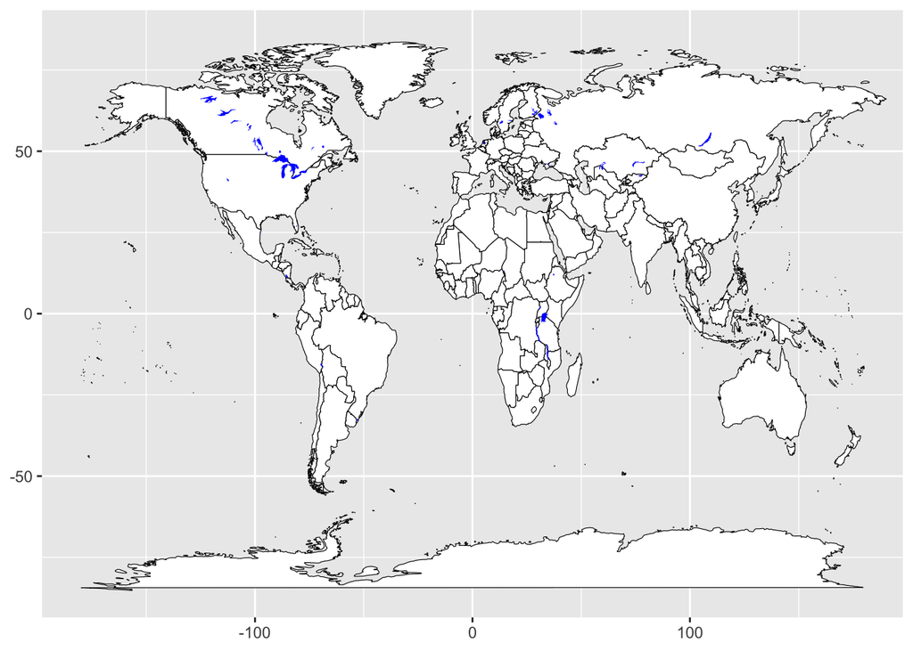

```r
ggplot(m1, aes(map_id = region)) +
  geom_map(data = m1, fill = "white", color = "black",
           linewidth = 0.2, alpha = 1, map = m1) +
  geom_map(data = m1lake, map = m1lake,
           fill = "blue", color = NA) +
  expand_limits(x = c(-180,180), y = c(-85, 85) )
```

Show just one region

```r
m2 <- m1 |> filter(region == "Canada")
m2 |> summarize(min_lat = min(lat), max_lat = max(lat),
                min_long = min(long), max_long = max(long))
```

```
##    min_lat  max_lat  min_long  max_long
## 1 41.67485 83.11611 -141.0022 -52.65366
```

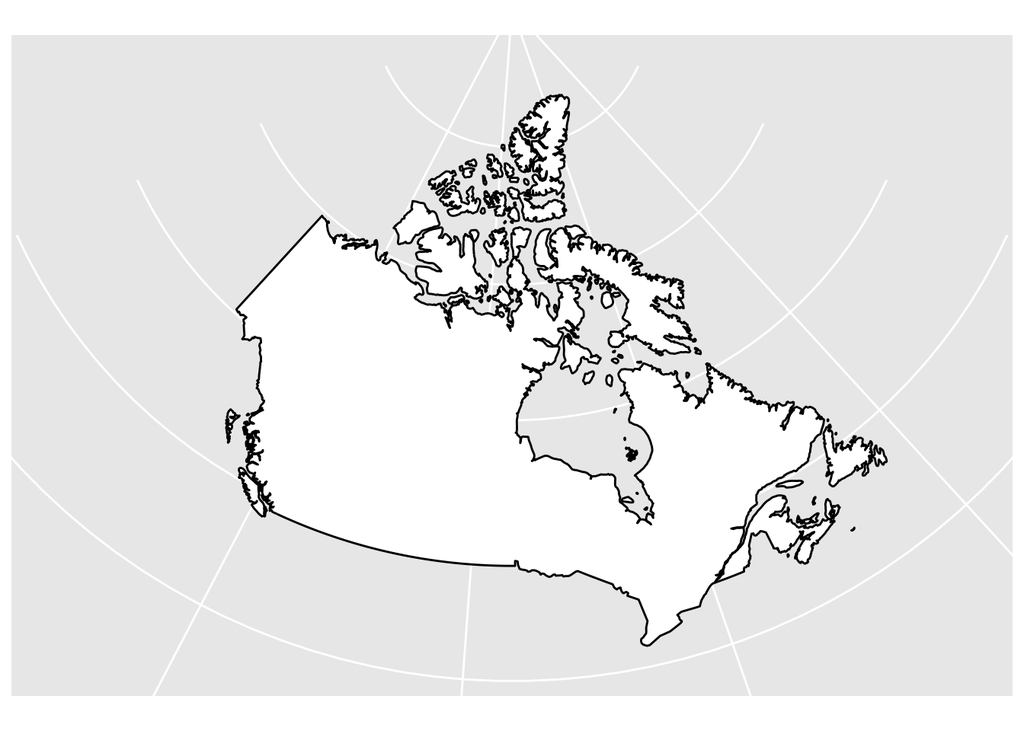

```r
ggplot(m2, aes(map_id = region)) +
  geom_map(fill = "white", color = "black", linewidth = 0.5, map = m2)  +
  coord_map("albers", 60, 90) +
  # coord_map("lambert", 42, 50) +
  theme(axis.title = element_blank(), axis.text = element_blank(),
        axis.ticks = element_blank()) +
  expand_limits(x = c(-141, -50), y = c(41, 85))
```

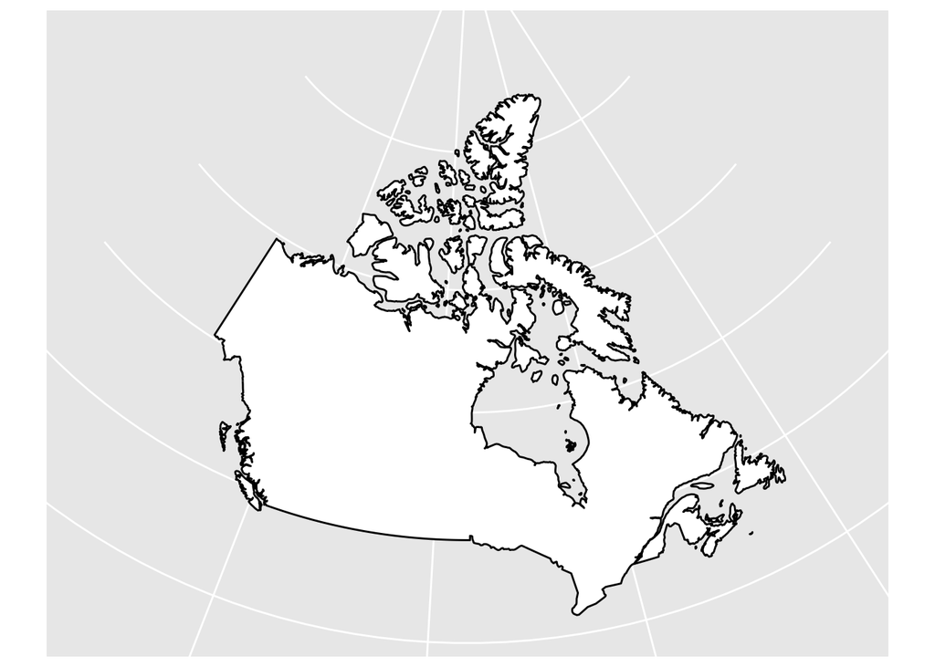

```r
ggplot(m2, aes(map_id = region)) +
  geom_map(fill = "white", color = "black", linewidth = 0.5, map = m2)  +
  coord_map("lambert", 42, 50) +
  theme(axis.title = element_blank(), axis.text = element_blank(),
        axis.ticks = element_blank()) +
  expand_limits(x = c(-141, -50), y = c(41, 85))
```

Note, this course is not making political statements when drawing maps.

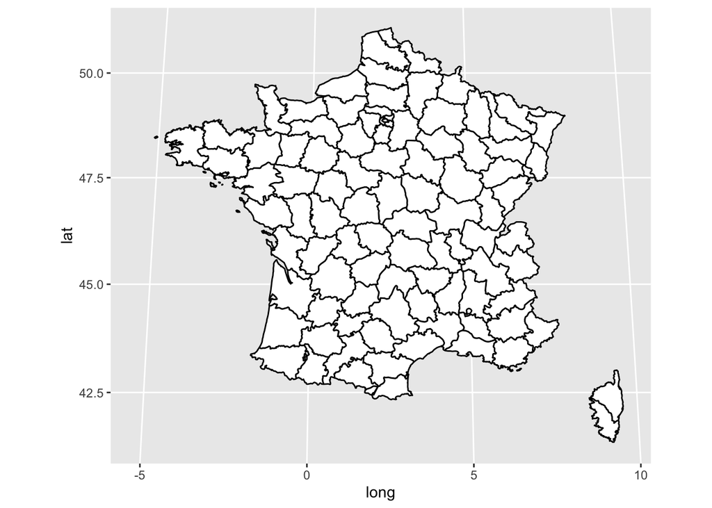

```r
m2 <- m1 |> filter(region == "Ukraine")
m2 <- m1 |> filter(region == "Iran")
m2 <- m1 |> filter(region == "Chile")
m2 <- m1 |> filter(region == "Israel")
m2 <- m1 |> filter(region == "Palestine")
m2 <- m1 |> filter(region == "China")
m2 <- m1 |> filter(region == "Taiwan")
m2 <- m1 |> filter(region == "USA")
m2 <- m1 |> filter(region == "USA", subregion == "Hawaii")
m2 <- map_data("usa")
m2 <- m1 |> filter(region == "France")
m2 <- map_data("france") # more detail
ggplot(m2, aes(map_id = region, x = long, y = lat)) +
  geom_map(fill = "white", color = "black", size = 0.5, map = m2) +
  coord_map("mollweide") +
  expand_limits(x = range(m2$long), y = range(m2$lat))
```

Sometimes it is useful to have a world map centred on the Pacific Ocean.

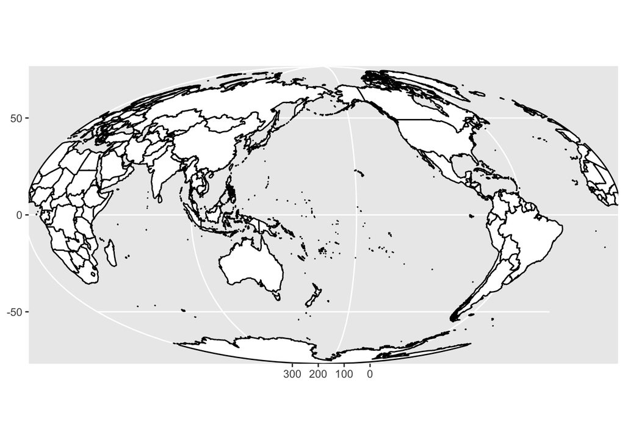

```r
m2 <- map_data("world2")
ggplot(m2, aes(map_id = region)) +
  geom_map(fill = "white", color = "black", size = 0.5, map = m2) +
  # coord_map("gilbert")
  expand_limits(x = c(0, 360), y = c(-90, 90)) +
  coord_map("mollweide")
```

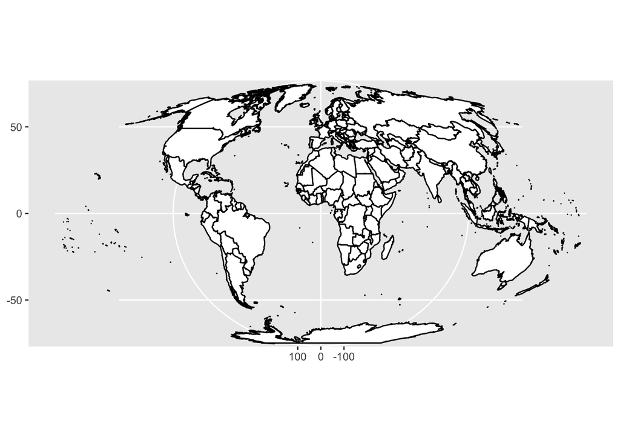

```r
  # coord_map("lambert", -25, 25) # not good for the whole globe
  # coord_map("albers", -25, 25)
m2 <- map_data("world")
ggplot(m2, aes(map_id = region)) +
  geom_map(fill = "white", color = "black", size = 0.5, map = m2) +
  # coord_map("gilbert")
  expand_limits(x = c(-180, 180), y = c(-90, 90)) +
  coord_map("mollweide")
```

```r
  # coord_map("lambert", -25, 25) # not good for the whole globe
  # coord_map("albers", -25, 25)
```

Get a list of projections from help(“mapproject”) (in `mapproj` package).

## Colouring regions

You can use a second data frame to add fill colours to a region. This second table must name the regions with the same codes as the map.

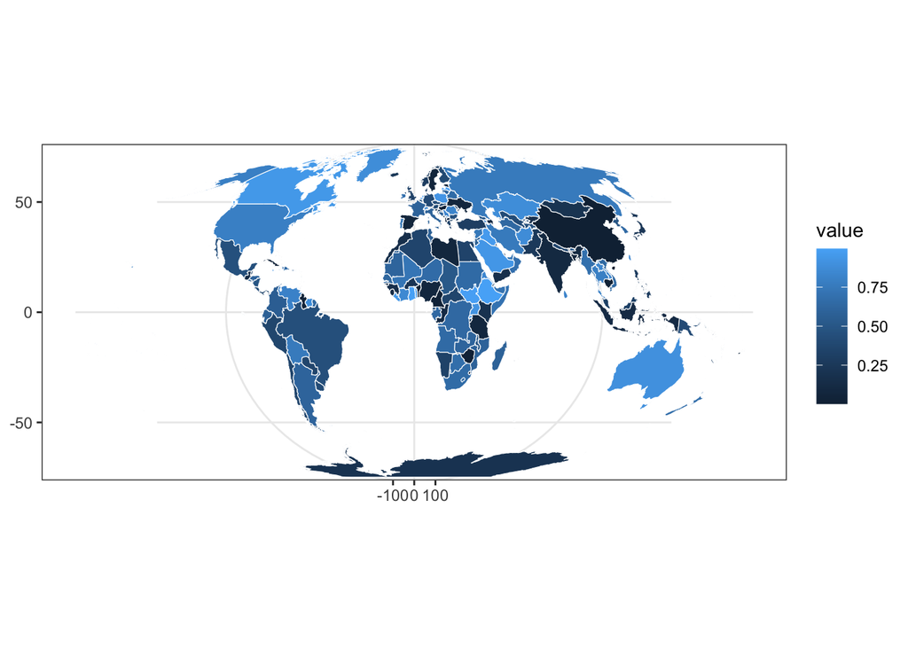

```r
values <- tibble( region = m1 |> pull(region) |> unique())
values <- values |> mutate(value = runif(nrow(values)))
map2 <- ggplot(values, aes(map_id = region)) +
        geom_map(aes(fill = value),
                 map = m1,
                 colour = "white",
                 alpha = 1, linewidth = 0.2) +
   expand_limits(x = c(-180,180), y = c(-80,80)) +
   theme_bw() +
  coord_map("mollweide")
map2
```

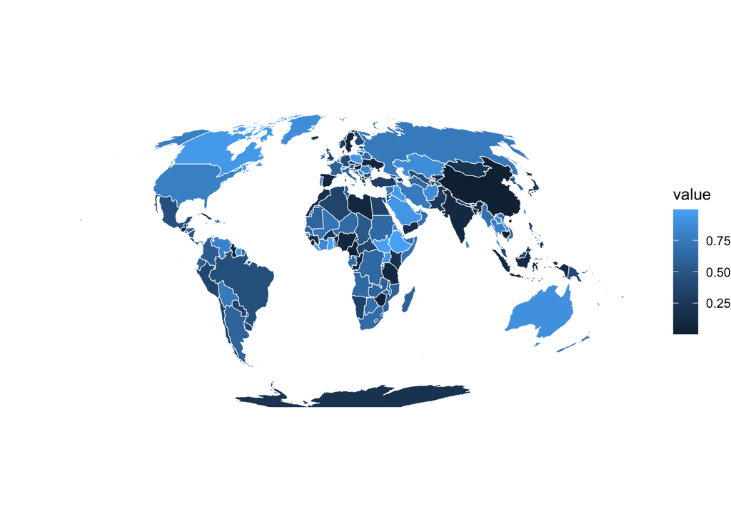

```r
map2 + theme_void() # removes axes, labels; leaves legend
```

Show just a few regions

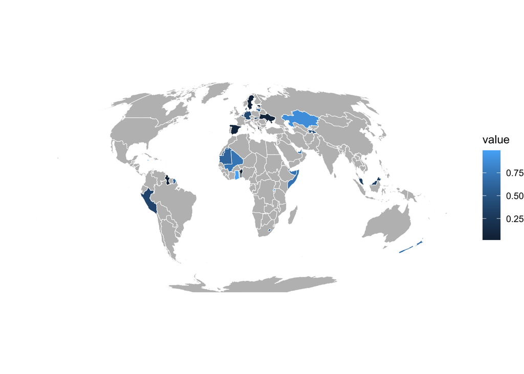

```r
map2 <- ggplot(m1, aes(map_id = region)) +
  geom_map(fill = "gray", color = "white", map = m1, linewidth = 0.2) +
  geom_map(aes(fill = value),
           data = values |> slice_sample(n = 50),
           map = m1,
           colour = "white", alpha = 1, size=0.2) +
   expand_limits(x = c(-180,180), y = c(-80,80)) +
   theme_bw() +
  coord_map("mollweide")
map2 + theme_void()
```

## Adding points

Start with some data:

```r
library(maps)
canada.cities |> head()
```

```
##            name country.etc    pop   lat    long capital
## 1 Abbotsford BC          BC 157795 49.06 -122.30       0
## 2      Acton ON          ON   8308 43.63  -80.03       0
## 3 Acton Vale QC          QC   5153 45.63  -72.57       0
## 4    Airdrie AB          AB  25863 51.30 -114.02       0
## 5    Aklavik NT          NT    643 68.22 -135.00       0
## 6    Albanel QC          QC   1090 48.87  -72.42       0
```

Add points to a map:

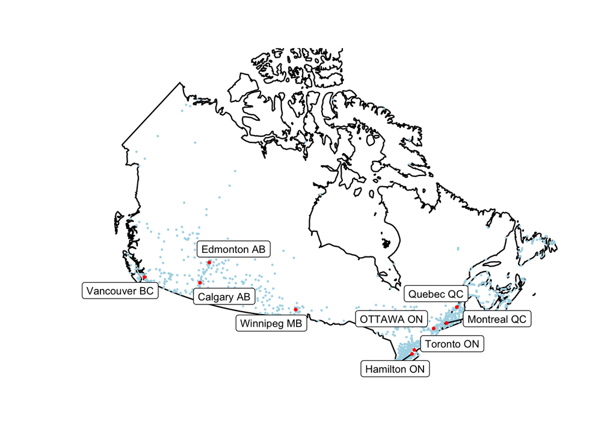

```r
library(ggrepel)
m2 <- m1 |> filter(region == "Canada")
ggplot(m2) +
  geom_map(aes(map_id = region),
           fill = "white", color = "black", linewidth = 0.5, map = m2) +
  geom_point(data = canada.cities,
             aes(x = long, y = lat),
             colour = "lightblue", size = 0.25) +
  geom_label_repel(data = canada.cities |> filter(pop > 500000),
             aes(x = long, y = lat, label = name),
             size = 3) +
  geom_point(data = canada.cities |> filter(pop > 500000),
             aes(x = long, y = lat),
             size = 0.75, color = "red") +
  coord_map("albers", 60, 90) +
  theme_void()
```